# Brazil 2000

12/21/2022

## Data

```r
old_adj <- read.csv('~/AmazonMalaria/Data/1_DataProcessing/LandscapeMetrics/LandscapeMetrics/PanAmaMuni_allclasses/metric_csv/adjacencymatrix/Brazil_2000.csv')

new_adj <- read.csv('~/AmazonMalaria/Data/1_DataProcessing/LandscapeMetrics/LandscapeMetrics_v3/PanAmaMuni_allclasses/metric_csv/adjacencymatrix/Brazil_2000.csv')
```

#### OLD

The land use categories for each land use layer are as follows: 0- Background (Not real class) 3- Forest Formation (Forest 1) 4- Savanna Formation (Forest 1) 5- Mangrove (Forest 1) 6- Flooded Forest (Forest 1) 11- Wetland (Non Forest Natural Formation 10) 12- Grassland (Non Forest Natural Formation 10) 13- Other non forest natural formation (Non Forest Natural Formation 10) 14- Farming (Farming 14) 22-Non-vegetatated area (Non vegetated area 22) 27- Non-observed (Non-observed 27) 32- Salt Flat (Non Forest Natural Formation 10) 33- River, Lake, and Ocean (Water 26) 34-Glacier (Water 26)

#### NEW

The land use categories for each land use layer are as follows: 0- Background (Not real class) 3- Forest Formation (Forest 1) 4- Savanna Formation (Forest 1) 5- Mangrove (Forest 1) 6- Flooded Forest (Forest 1) 11- Wetland (Non Forest Natural Formation 10) 12- Grassland (Non Forest Natural Formation 10) 13- Other non forest natural formation (Non Forest Natural Formation 10) 14- Farming (Farming 14) 22- Non-vegetatated area (Non vegetated area 22) 24- Urban Infrastructure (Non vegetated area 22) 25- Other Non Vegetated Area (Non vegetated area 22) 27- Non Observed (Non Observed 27) 29- Rocky Outcrop (Non Forest Natural Formation 10) 30- Mining (Non vegetated area 22) 32- Salt Flat (Non Forest Natural Formation 10) 33- River, Lake, and Ocean (Water 26) 34- Glacier (Water 26)

```r
library(reshape)
old_adj_melted <- old_adj %>%
  mutate(Land_Cover_Row_Name = case_when(Land_Cover_Row == 0 ~ "Background",
                                         Land_Cover_Row == 3 ~ "Forest",
                                         Land_Cover_Row == 4 ~ "Savanna",
                                         Land_Cover_Row == 5 ~ "Mangrove",
                                         Land_Cover_Row == 6 ~ "Floodedforest",
                                         Land_Cover_Row == 11 ~ "Wetland",
                                         Land_Cover_Row == 12 ~ "Grassland",
                                         Land_Cover_Row == 13 ~ "Othernonforest",
                                         Land_Cover_Row == 14 ~ "Farming",
                                         Land_Cover_Row == 22 ~ "Nonveg",
                                         Land_Cover_Row == 27 ~ "Nonobserv",
                                         Land_Cover_Row == 32 ~ "Saltflat",
                                         Land_Cover_Row == 33 ~ "Riverlakeocean",
                                         Land_Cover_Row == 34 ~ "Glacier") %>%
           as.factor(),
         Land_Cover_Column_Name = case_when(Land_Cover_Column == 0 ~ "Background",
                                            Land_Cover_Column == 3 ~ "Forest",
                                            Land_Cover_Column == 4 ~ "Savanna",
                                            Land_Cover_Column == 5 ~ "Mangrove",
                                            Land_Cover_Column == 6 ~ "Floodedforest",
                                            Land_Cover_Column == 11 ~ "Wetland",
                                            Land_Cover_Column == 12 ~ "Grassland",
                                            Land_Cover_Column == 13 ~ "Othernonforest",
                                            Land_Cover_Column == 14 ~ "Farming",
                                            Land_Cover_Column == 22 ~ "Nonveg",
                                            Land_Cover_Column == 27 ~ "Nonobserv",
                                            Land_Cover_Column == 32 ~ "Saltflat",
                                            Land_Cover_Column == 33 ~ "Riverlakeocean",
                                            Land_Cover_Column == 34 ~ "Glacier") %>%
           as.factor(),
         Metric_Name = paste0(Land_Cover_Column_Name, "_", Land_Cover_Row_Name) %>%
           as.factor())

new_adj_melted <- new_adj %>%
  mutate(Land_Cover_Row_Name = case_when(Land_Cover_Row == 0 ~ "Background",
                                         Land_Cover_Row == 3 ~ "Forest",
                                         Land_Cover_Row == 4 ~ "Savanna",
                                         Land_Cover_Row == 5 ~ "Mangrove",
                                         Land_Cover_Row == 6 ~ "Floodedforest",
                                         Land_Cover_Row == 10 ~ "Nonforest",
                                         Land_Cover_Row == 11 ~ "Wetland",
                                         Land_Cover_Row == 12 ~ "Grassland",
                                         Land_Cover_Row == 13 ~ "Othernonforest",
                                         Land_Cover_Row == 14 ~ "Farming",
                                         Land_Cover_Row == 22 ~ "Nonveg",
                                         Land_Cover_Row == 24 ~ "Urban",
                                         Land_Cover_Row == 25 ~ "Othernonveg",
                                         Land_Cover_Row == 27 ~ "Nonobserv",
                                         Land_Cover_Row == 29 ~ "Outcrop",
                                         Land_Cover_Row == 30 ~ "Mining",
                                         Land_Cover_Row == 32 ~ "Saltflat",
                                         Land_Cover_Row == 33 ~ "Riverlakeocean",
                                         Land_Cover_Row == 34 ~ "Glacier") %>%
           as.factor(),
         Land_Cover_Column_Name = case_when(Land_Cover_Column == 0 ~ "Background",
                                            Land_Cover_Column == 3 ~ "Forest",
                                            Land_Cover_Column == 4 ~ "Savanna",
                                            Land_Cover_Column == 5 ~ "Mangrove",
                                            Land_Cover_Column == 6 ~ "Floodedforest",
                                            Land_Cover_Column == 10 ~ "Nonforest",
                                            Land_Cover_Column == 11 ~ "Wetland",
                                            Land_Cover_Column == 12 ~ "Grassland",
                                            Land_Cover_Column == 13 ~ "Othernonforest",
                                            Land_Cover_Column == 14 ~ "Farming",
                                            Land_Cover_Column == 22 ~ "Nonveg",
                                            Land_Cover_Column == 24 ~ "Urban",
                                            Land_Cover_Column == 25 ~ "Othernonveg",
                                            Land_Cover_Column == 27 ~ "Nonobserv",
                                            Land_Cover_Column == 29 ~ "Outcrop",
                                            Land_Cover_Column == 30 ~ "Mining",
                                            Land_Cover_Column == 32 ~ "Saltflat",
                                            Land_Cover_Column == 33 ~ "Riverlakeocean",
                                            Land_Cover_Column == 34 ~ "Glacier") %>%
           as.factor(),
         Metric_Name = paste0(Land_Cover_Column_Name, "_", Land_Cover_Row_Name) %>%
           as.factor())

old_adj_melted_v2 <- old_adj_melted %>%
  melt(id = c("Muni_ID", "Country", "Year", "Metric_Name"),
       measure.vars = "EdgeCounts") %>%
  pivot_wider(id_cols = c("Muni_ID", "Country", "Year"),
              names_from = "Metric_Name",
              values_from = "value") %>%
  mutate_all(~replace_na(., 0))
new_adj_melted_v2 <- new_adj_melted %>%
  melt(id = c("Muni_ID", "Country", "Year", "Metric_Name"),
       measure.vars = "EdgeCounts") %>%
  pivot_wider(id_cols = c("Muni_ID", "Country", "Year"),
              names_from = "Metric_Name",
              values_from = "value") %>%
  mutate_all(~replace_na(., 0))
old_adj_melted_v3 <- old_adj_melted_v2 %>%
  dplyr::select(intersect(colnames(old_adj_melted_v2), colnames(new_adj_melted_v2)))

new_adj_melted_v3 <- new_adj_melted_v2 %>%
  dplyr::select(intersect(colnames(old_adj_melted_v2), colnames(new_adj_melted_v2)))

old_adj_melted_v3
```

```
## # A tibble: 935 × 65
##    Muni_ID Country  Year Fores…¹ Fores…² Fores…³ Fores…⁴ Fores…⁵ Other…⁶ Other…⁷
##      <dbl> <fct>   <dbl>   <dbl>   <dbl>   <dbl>   <dbl>   <dbl>   <dbl>   <dbl>
##  1 1100015 Brazil   2000  2.18e7  208681  260014      39   11788 3694580   89400
##  2 1100023 Brazil   2000  9.86e6    1902  356826      60    7942    7448    5041
##  3 1100031 Brazil   2000  2.77e6    2271  114334       0    4281   32422    9017
##  4 1100049 Brazil   2000  7.54e6     567  277943      46    6496    1666     429
##  5 1100056 Brazil   2000  4.71e6   53825  162234       5     810 4413402   90709
##  6 1100064 Brazil   2000  1.99e6    1320  138045      13     773   18444   13317
##  7 1100072 Brazil   2000  5.76e6    1266  213170      61    4144   25720   18103
##  8 1100080 Brazil   2000  2.06e7   32823  125938      54   25957  218154   35664
##  9 1100098 Brazil   2000  1.24e7     295  330351      24   18801    2480    2251
## 10 1100106 Brazil   2000  1.06e8  126187  399990     207  109464 1598786   74420
## # … with 925 more rows, 55 more variables: Othernonforest_Nonobserv <dbl>,
## #   Othernonforest_Riverlakeocean <dbl>, Farming_Farming <dbl>,
## #   Farming_Nonobserv <dbl>, Farming_Riverlakeocean <dbl>,
## #   Nonobserv_Nonobserv <dbl>, Nonobserv_Riverlakeocean <dbl>,
## #   Riverlakeocean_Riverlakeocean <dbl>, Forest_Savanna <dbl>,
## #   Forest_Grassland <dbl>, Savanna_Savanna <dbl>, Savanna_Grassland <dbl>,
## #   Savanna_Othernonforest <dbl>, Savanna_Farming <dbl>, …
```

```r
new_adj_melted_v3
```

```
## # A tibble: 935 × 65
##    Muni_ID Country  Year Fores…¹ Fores…² Fores…³ Fores…⁴ Fores…⁵ Other…⁶ Other…⁷
##      <dbl> <fct>   <dbl>   <dbl>   <dbl>   <dbl>   <dbl>   <dbl>   <dbl>   <dbl>
##  1 1100015 Brazil   2000  1.88e7       0  389286      77   18195       0       0
##  2 1100023 Brazil   2000  9.00e6       0  389021      27    4874       0       0
##  3 1100031 Brazil   2000  2.15e6       0  117871       8    4523       0       0
##  4 1100049 Brazil   2000  6.92e6       0  303808      11    9106       0       0
##  5 1100056 Brazil   2000  3.69e6       0  119484       0     666       0       0
##  6 1100064 Brazil   2000  1.42e6       0  124487      46     734       0       0
##  7 1100072 Brazil   2000  4.62e6       0  210896       0     733       0       0
##  8 1100080 Brazil   2000  1.88e7       0  189422      69   21308       0       0
##  9 1100098 Brazil   2000  1.13e7       0  358055       0   31080       0       0
## 10 1100106 Brazil   2000  1.02e8       0  354621     154   90387       0       0
## # … with 925 more rows, 55 more variables: Othernonforest_Nonobserv <dbl>,
## #   Othernonforest_Riverlakeocean <dbl>, Farming_Farming <dbl>,
## #   Farming_Nonobserv <dbl>, Farming_Riverlakeocean <dbl>,
## #   Nonobserv_Nonobserv <dbl>, Nonobserv_Riverlakeocean <dbl>,
## #   Riverlakeocean_Riverlakeocean <dbl>, Forest_Savanna <dbl>,
## #   Forest_Grassland <dbl>, Savanna_Savanna <dbl>, Savanna_Grassland <dbl>,
## #   Savanna_Othernonforest <dbl>, Savanna_Farming <dbl>, …
```

```r
old_adj_melted_v4 <- old_adj_melted_v3 %>%
  dplyr::select(where(is.numeric), - Year, - Wetland_Othernonforest, - Background_Othernonforest, - Muni_ID)
                # , - Floodedforest_Othernonforest, Floodedforest_Nonobserv, Floodedforest_Grassland)


new_adj_melted_v4 <- new_adj_melted_v3 %>%
  dplyr::select(where(is.numeric), - Year, - Wetland_Othernonforest, - Background_Othernonforest, - Muni_ID)
                # , - Floodedforest_Othernonforest, Floodedforest_Nonobserv, Floodedforest_Grassland)



cor(old_adj_melted_v4, new_adj_melted_v4, method = 'pearson') %>%
  diag() %>%
  as.data.frame() %>%
  filter(!is.na(.)) %>%
  summary()
```

```
##        .
##  Min.   :-0.05224
##  1st Qu.: 0.15369
##  Median : 0.53075
##  Mean   : 0.52874
##  3rd Qu.: 0.92206
##  Max.   : 1.00000
```

Unsure why the correlation is not close to one.

## Class Metrics

### data

```r
old_class <- read_csv('~/AmazonMalaria/Data/1_DataProcessing/LandscapeMetrics/LandscapeMetrics/PanAmaMuni_allclasses/metric_csv/classmetrics/Brazil_2000.csv') %>%
  filter(class == 3) %>%
  dplyr::select(-c(layer, id, level, class))
new_class <- read_csv('~/AmazonMalaria/Data/1_DataProcessing/LandscapeMetrics/LandscapeMetrics_v3/PanAmaMuni_allclasses/metric_csv/classmetrics/Brazil_2000.csv') %>%
  filter(class == 3) %>%
  dplyr::select(-c(layer, id, level, class))
new_class[!complete.cases(new_class),]
```

```
## # A tibble: 4 × 5
##   Muni_ID Country  Year metric value
##     <dbl> <chr>   <dbl> <chr>  <dbl>
## 1 2200806 Brazil   2000 enn_mn    NA
## 2 2903201 Brazil   2000 enn_mn    NA
## 3 2919553 Brazil   2000 enn_mn    NA
## 4 5003306 Brazil   2000 enn_mn    NA
```

```r
old_class[!complete.cases(old_class),]
```

```
## # A tibble: 1 × 5
##   Muni_ID Country  Year metric value
##     <dbl> <chr>   <dbl> <chr>  <dbl>
## 1 2107902 Brazil   2000 enn_mn    NA
```

```r
old_class_v2 <- old_class %>%
  pivot_wider(
    id_cols = c('Muni_ID', 'Country', 'Year'),
    names_from = 'metric',
    values_from = 'value'
  ) %>%
  dplyr::rename(pland_forest = pland,
                area_mn_forest = area_mn,
                te_forest = te,
                enn_mn_forest = enn_mn)

new_class_v2 <- new_class %>%
  pivot_wider(
    id_cols = c('Muni_ID', 'Country', 'Year'),
    names_from = 'metric',
    values_from = 'value'
  ) %>%
  dplyr::rename(pland_forest = pland,
                area_mn_forest = area_mn,
                te_forest = te,
                enn_mn_forest = enn_mn)

merged_class <- merge(old_class_v2, new_class_v2,
                      by = c('Muni_ID', 'Country', 'Year'),
                      suffixes = c('_old', '_new'))
```

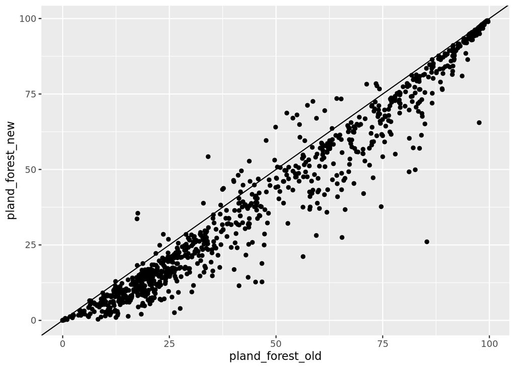

```r
ggplot(merged_class) +
  geom_point(aes(x = pland_forest_old,
                 y = pland_forest_new)) +
  geom_abline(slope = 1)
```

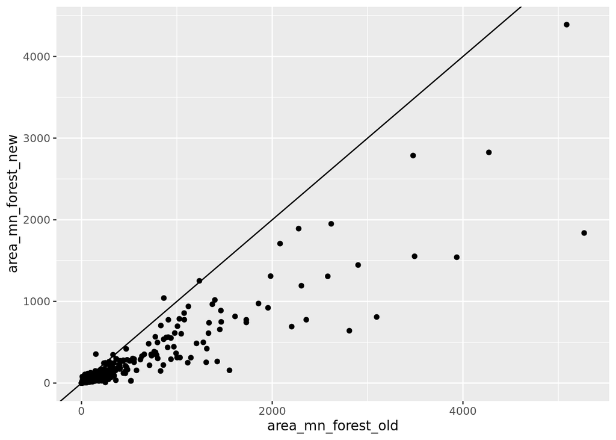

```r
ggplot(merged_class) +
  geom_point(aes(x = area_mn_forest_old,
                 y = area_mn_forest_new)) +
  geom_abline(slope = 1)
```

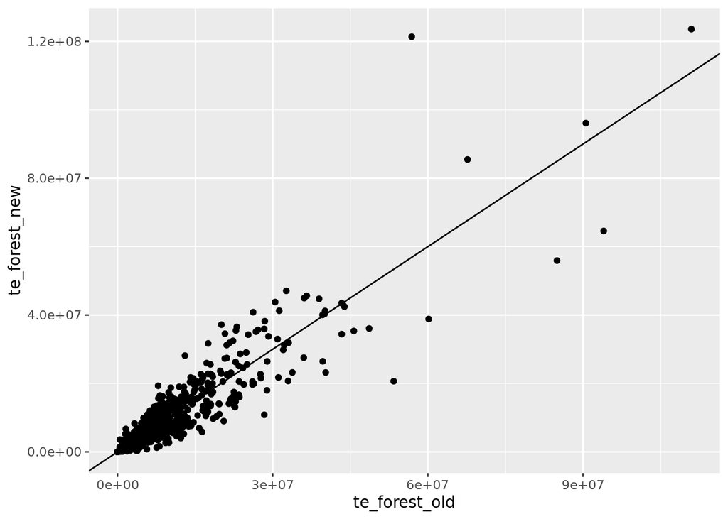

```r
ggplot(merged_class) +
  geom_point(aes(x = te_forest_old,
                 y = te_forest_new)) +
  geom_abline(slope = 1)
```

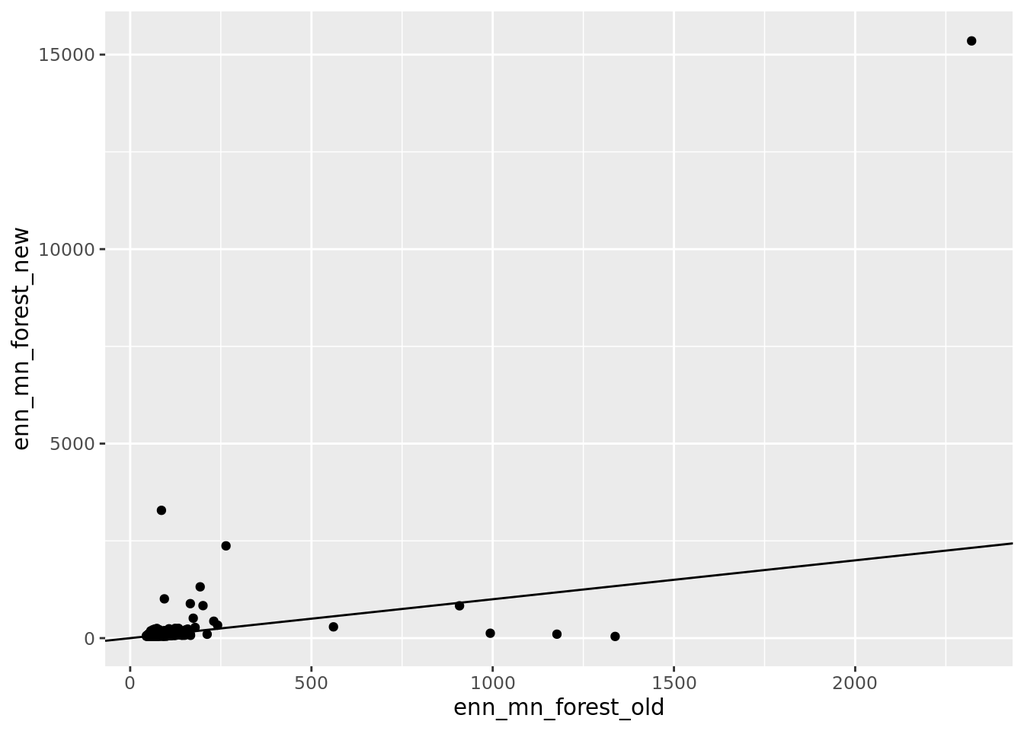

```r
ggplot(merged_class) +
  geom_point(aes(x = enn_mn_forest_old,
                 y = enn_mn_forest_new)) +
  geom_abline(slope = 1)
```

#### Statistical testing

We attempt to test if $\mu_{\text{old}} = \mu_{\text{new}}$ or $\mu_{d} = 0$. We know the observations are independent of each other, more or less depending on if we take spatiality into account. We now need to test if each variable is normally distributed to see if we can perform a two-sample t-test.

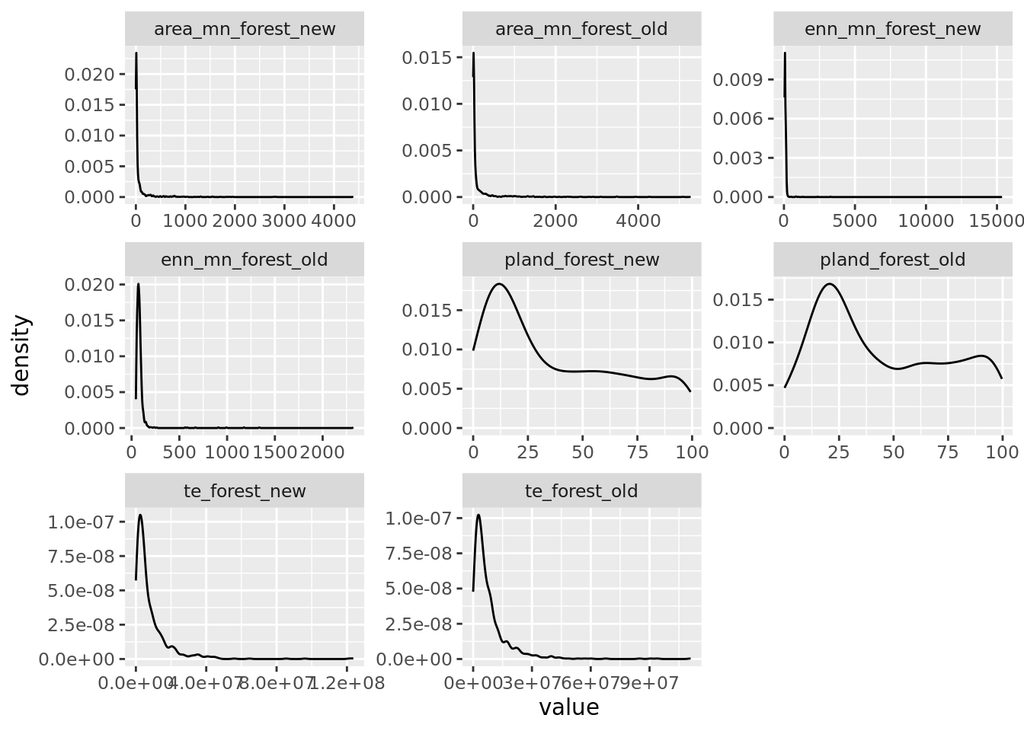

```r
merged_class %>%
  dplyr::select(-c(Year, Muni_ID)) %>%
  keep(is.numeric) %>%
  gather() %>%
  ggplot(aes(value)) +
  facet_wrap(~ key, scales = 'free') +
  geom_density()
```

Each variable is not normally distributed, so we turn to the nonparametric Mann-Whitney-Wilcoxon Test.

```r
wilcox.test(merged_class$area_mn_forest_old, merged_class$area_mn_forest_new, paired = T)
```

```
##
##  Wilcoxon signed rank test with continuity correction
##
## data:  merged_class$area_mn_forest_old and merged_class$area_mn_forest_new
## V = 347231, p-value < 2.2e-16
## alternative hypothesis: true location shift is not equal to 0
```

```r
wilcox.test(merged_class$enn_mn_forest_old, merged_class$enn_mn_forest_new, paired = T)
```

```
##
##  Wilcoxon signed rank test with continuity correction
##
## data:  merged_class$enn_mn_forest_old and merged_class$enn_mn_forest_new
## V = 139226, p-value < 2.2e-16
## alternative hypothesis: true location shift is not equal to 0
```

```r
wilcox.test(merged_class$pland_forest_old, merged_class$pland_forest_new, paired = T)
```

```
##
##  Wilcoxon signed rank test with continuity correction
##
## data:  merged_class$pland_forest_old and merged_class$pland_forest_new
## V = 415504, p-value < 2.2e-16
## alternative hypothesis: true location shift is not equal to 0
```

```r
wilcox.test(merged_class$te_forest_old, merged_class$te_forest_new, paired = T)
```

```
##
##  Wilcoxon signed rank test with continuity correction
##
## data:  merged_class$te_forest_old and merged_class$te_forest_new
## V = 231312, p-value = 0.1022
## alternative hypothesis: true location shift is not equal to 0
```

The only variable that is above the significance level of $\alpha = 0.05$ is `te_forest`. That is, every other variable pair — `area_mn_forest`, `enn_mn_forest`, and `pland_forest` — are statistically different. We can then conclude that with $\alpha = 0.05$, the two data sets are statistically different and must be redone.